# ggpol Guide

## GeomCircle

`geom_circle` plots circle-polygons with a specified radius, rather than `size` in `geom_point`. As such, this is also by default used by `geom_parliament`.

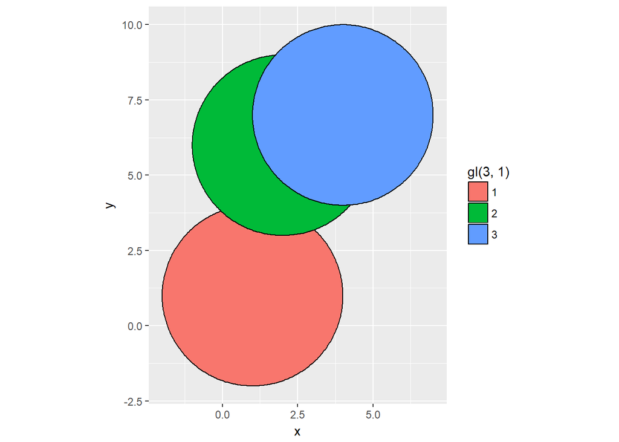

```r
df <- data.frame(x = sample(1:10, 3), y = sample(1:10, 3),
                 r = sample(3:4, 3, replace = TRUE))

ggplot(df) + geom_circle(aes(x = x, y = y, r = r, fill = gl(3, 1))) +
  coord_fixed()
```

## GeomTshighlight

`geom_tshighlight` (for timeseries-highlight) is a wrapper around `geom_rect` that uses default values for `ymin` and `ymax` so that it spans the entire y-axis.

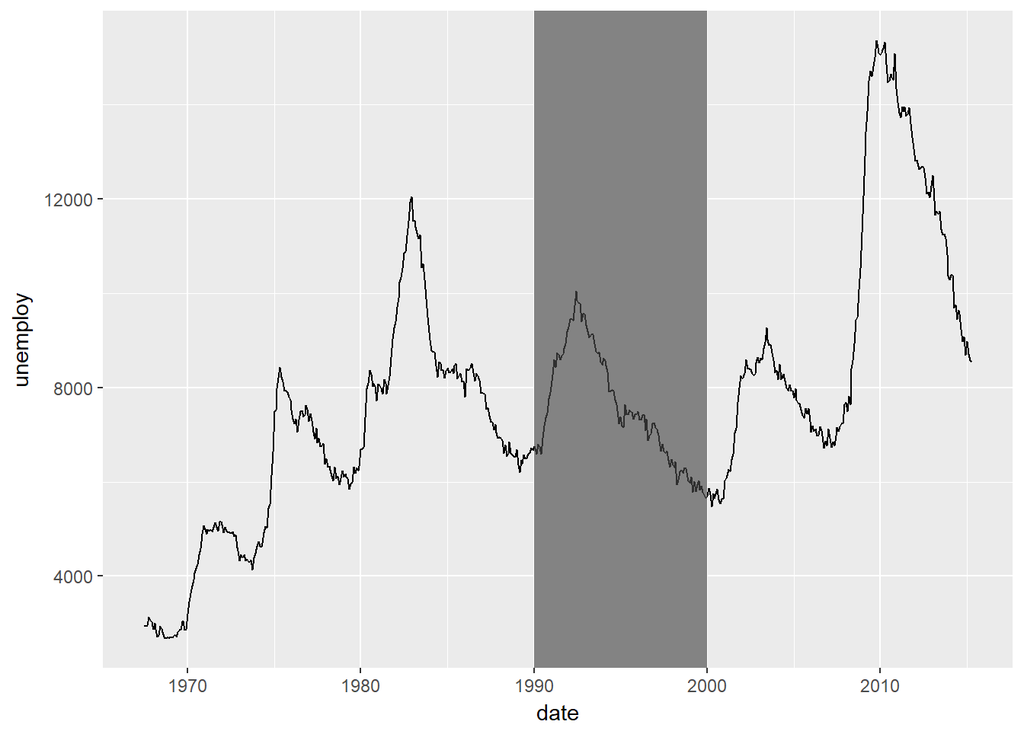

```r
ggplot(economics, aes(x = date, y = unemploy)) +
  geom_line() +
  geom_tshighlight(aes(xmin = as.Date("01/01/1990", format = "%d/%m/%Y"),
                       xmax = as.Date("01/01/2000", format = "%d/%m/%Y")),
                   alpha = 0.01)
```

## GeomBoxjitter

`geom_boxjitter` plots a hybrid boxplot - half boxplot, half scatterplot - with optional errorbars. The jitter is customizable vertically and horizontally and also supports a `seed` argument. Note that, if you specify e.g. `fill` for the boxplot, you need to select a `jitter.shape` that actually supports this. Shapes 21-25 support fill, and 21 is a circle.

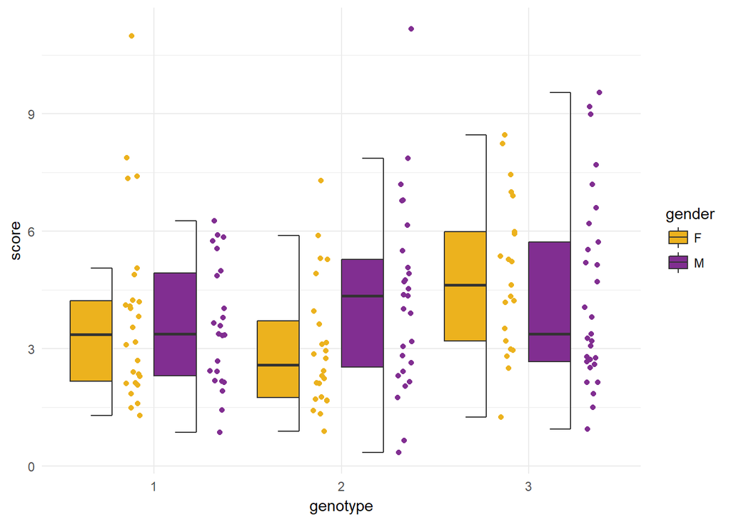

```r
df <- data.frame(score = rgamma(150, 4, 1),
                 gender = sample(c("M", "F"), 150, replace = TRUE),
                 genotype = factor(sample(1:3, 150, replace = TRUE)))

ggplot(df) +
  geom_boxjitter(aes(x = genotype, y = score, fill = gender),
                 jitter.shape = 21, jitter.color = NA,
                 jitter.height = 0, jitter.width = 0.04,
                 outlier.color = NA, errorbar.draw = TRUE) +
  scale_fill_manual(values = c("#ecb21e", "#812e91")) +
  theme_minimal()
```

By default, outliers are a normal part of the jitterplot. We might want to highlight them, which can be done by setting `outlier.intersect` to `TRUE`. We also select a different outlier shape to clearly differentiate them from the scatter points.

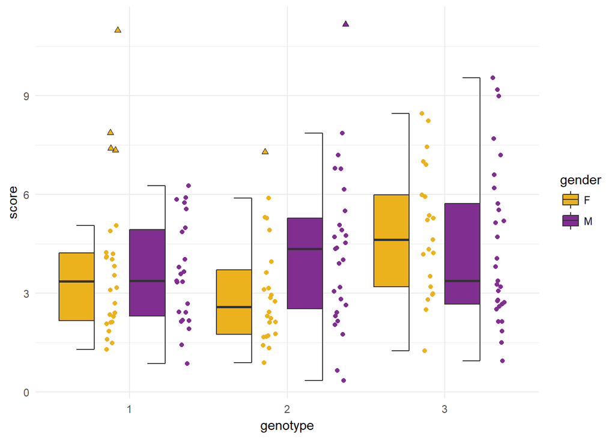

```r
ggplot(df) +
  geom_boxjitter(aes(x = genotype, y = score, fill = gender),
                 jitter.shape = 21, jitter.color = NA,
                 jitter.height = 0, jitter.width = 0.04,
                 outlier.color = "black", errorbar.draw = TRUE,
                 outlier.intersect = TRUE, outlier.shape = 24,
                 outlier.size = 1.5) +
  scale_fill_manual(values = c("#ecb21e", "#812e91")) +
  theme_minimal()
```

It is also possible to hide the jitter altogether by setting `boxplot.expand` to `TRUE`.. In that case, `geom_boxjitter` is equal to `geom_boxplot`, but has additional, configurable errorbars.

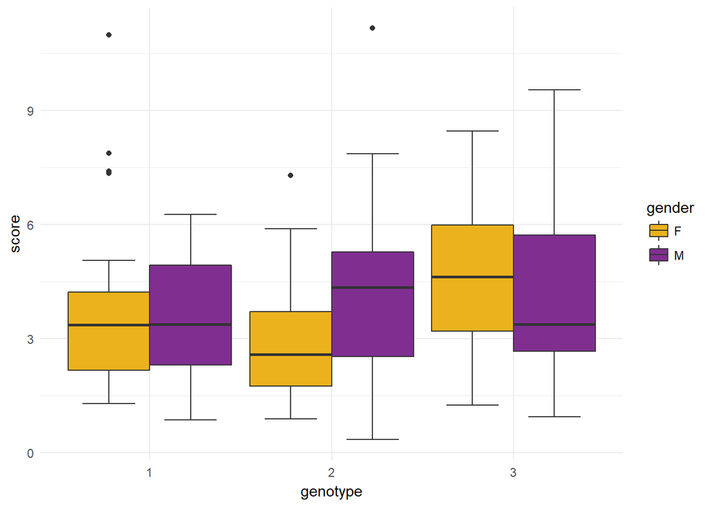

```r
ggplot(df) +
  geom_boxjitter(aes(x = genotype, y = score, fill = gender),
                 errorbar.draw = TRUE, boxplot.expand = TRUE,
                 errorbar.length = 0.4) +
  scale_fill_manual(values = c("#ecb21e", "#812e91")) +
  theme_minimal()
```

## FacetShare

`facet_share` is an experimental feature that implements basic shared axes for `FacetWrap` with only two panels (i.e., this will not work if you stratify by a variable with more than 2 levels). If we want to mirror our axis, we will have to multiply one panel by -1 (the choice of which panel to multiply by -1 is natural, i.e. the left one for horizontal, and the bottom one for vertical directions). Since this will also change the axis labels for that panel, setting `reverse_num` to `TRUE` will reverse this change.

The horizontal mirroring also requires using `coord_flip()`.

Naturally, the shared axis is well suited for population pyramids.

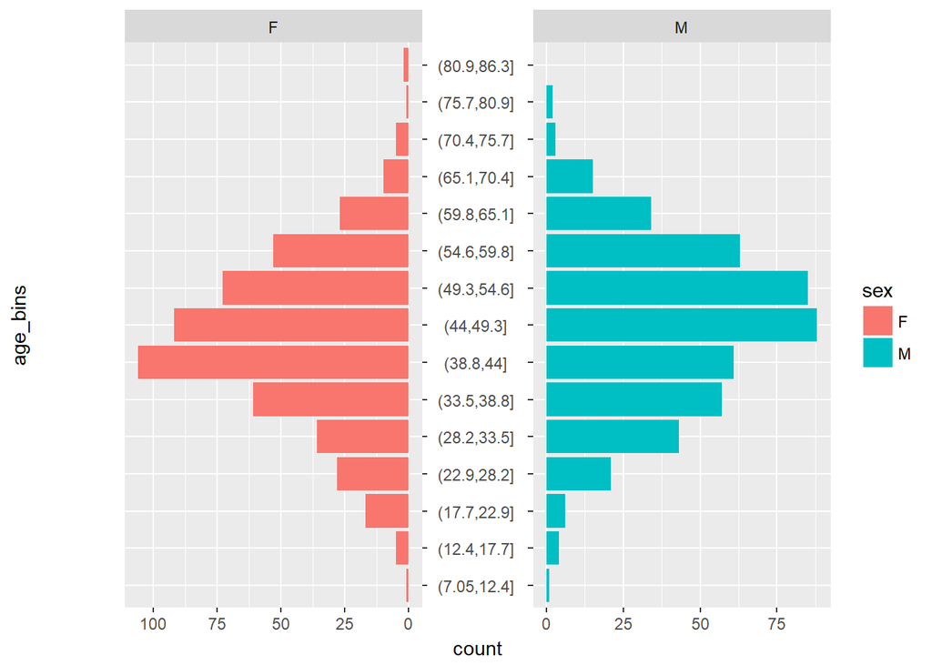

```r
df <- data.frame(sex = sample(c("M", "F"), 1000, replace = TRUE),
                 age = rnorm(1000, 45, 12))

df$age_bins <- cut(df$age, 15)
df$count <- 1
df <- aggregate(count ~ sex + age_bins, data = df, length)


df_h <- df
df_h$count <- ifelse(df_h$sex == "F", df_h$count * -1, df_h$count)

ggplot(df_h, aes(x = age_bins, y = count, fill = sex)) +
  geom_bar(stat = "identity") +
  facet_share(~sex, dir = "h", scales = "free", reverse_num = TRUE) +
  coord_flip()
```

And vertically:

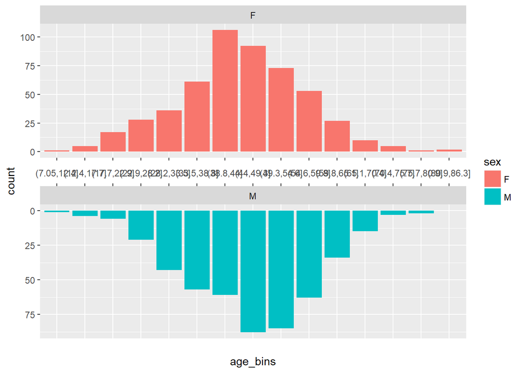

```r
# When setting direction to vertical, and if we want to mirror the second panel,
# we must multiply the second factor by -1.
# And levels(factor(gender))[2] is M.
df_v <- df
df_v$count <- ifelse(df_v$sex == "M", df_v$count * -1, df_v$count)
ggplot(df_v, aes(x = age_bins, y = count, fill = sex)) +
  geom_bar(stat = "identity") +
  facet_share(~sex, dir = "v", scales = "free", reverse_num = TRUE)
```